# Optimal Treatment Analysis

## Outcome Variable

**Outcome Variable:** haz

## Predictor Variables

**Intervention Variable:** earlybf

**Adjustment Set:**

- arm
- sex
- W_mage
- meducyrs
- feducyrs
- hhwealth_quart
- hfoodsec
- W_mhtcm
- W_mwtkg
- W_mbmi
- vagbrth
- W_gagebrth
- W_birthwt
- W_birthlen
- W_nrooms
- W_nchldlt5
- brthmon
- W_parity
- impfloor
- impsan
- safeh20
- delta_W_mage
- delta_meducyrs
- delta_feducyrs
- delta_hhwealth_quart
- delta_hfoodsec
- delta_W_mhtcm
- delta_W_mwtkg
- delta_W_mbmi
- delta_vagbrth
- delta_W_gagebrth
- delta_W_birthwt
- delta_W_birthlen
- delta_W_nrooms
- delta_W_nchldlt5
- delta_brthmon
- delta_W_parity
- delta_impfloor
- delta_impsan
- delta_safeh20

## Stratifying Variables

The analysis was stratified on these variable(s):

- agecat
- studyid
- country

## Data Summary

| agecat | studyid | country | earlybf | n_cell | n |
| --- | --- | --- | --- | --- | --- |
| Birth | EE | PAKISTAN | 1 | 44 | 229 |
| Birth | EE | PAKISTAN | 0 | 185 | 229 |
| Birth | GMS-Nepal | NEPAL | 1 | 180 | 632 |
| Birth | GMS-Nepal | NEPAL | 0 | 452 | 632 |
| Birth | JiVitA-3 | BANGLADESH | 1 | 236 | 22370 |
| Birth | JiVitA-3 | BANGLADESH | 0 | 22134 | 22370 |
| Birth | JiVitA-4 | BANGLADESH | 1 | 1912 | 2823 |
| Birth | JiVitA-4 | BANGLADESH | 0 | 911 | 2823 |
| Birth | MAL-ED | BANGLADESH | 1 | 147 | 230 |
| Birth | MAL-ED | BANGLADESH | 0 | 83 | 230 |
| Birth | MAL-ED | BRAZIL | 1 | 28 | 65 |
| Birth | MAL-ED | BRAZIL | 0 | 37 | 65 |
| Birth | MAL-ED | INDIA | 1 | 32 | 46 |
| Birth | MAL-ED | INDIA | 0 | 14 | 46 |
| Birth | MAL-ED | NEPAL | 1 | 14 | 27 |
| Birth | MAL-ED | NEPAL | 0 | 13 | 27 |
| Birth | MAL-ED | PERU | 1 | 175 | 233 |
| Birth | MAL-ED | PERU | 0 | 58 | 233 |
| Birth | MAL-ED | SOUTH AFRICA | 1 | 69 | 111 |
| Birth | MAL-ED | SOUTH AFRICA | 0 | 42 | 111 |
| Birth | MAL-ED | TANZANIA, UNITED REPUBLIC OF | 1 | 111 | 125 |
| Birth | MAL-ED | TANZANIA, UNITED REPUBLIC OF | 0 | 14 | 125 |
| Birth | NIH-Crypto | BANGLADESH | 1 | 634 | 732 |
| Birth | NIH-Crypto | BANGLADESH | 0 | 98 | 732 |
| Birth | SAS-CompFeed | INDIA | 1 | 86 | 1207 |
| Birth | SAS-CompFeed | INDIA | 0 | 1121 | 1207 |
| Birth | ZVITAMBO | ZIMBABWE | 1 | 6556 | 12354 |
| Birth | ZVITAMBO | ZIMBABWE | 0 | 5798 | 12354 |
| 6 months | EE | PAKISTAN | 1 | 68 | 362 |
| 6 months | EE | PAKISTAN | 0 | 294 | 362 |

[output cut: 52 more lines]

The following strata were considered:

- agecat: 24 months, studyid: EE, country: PAKISTAN
- agecat: 24 months, studyid: GMS-Nepal, country: NEPAL
- agecat: 24 months, studyid: JiVitA-3, country: BANGLADESH
- agecat: 24 months, studyid: JiVitA-4, country: BANGLADESH
- agecat: 24 months, studyid: MAL-ED, country: BANGLADESH
- agecat: 24 months, studyid: MAL-ED, country: BRAZIL
- agecat: 24 months, studyid: MAL-ED, country: INDIA
- agecat: 24 months, studyid: MAL-ED, country: NEPAL
- agecat: 24 months, studyid: MAL-ED, country: PERU
- agecat: 24 months, studyid: MAL-ED, country: SOUTH AFRICA
- agecat: 24 months, studyid: MAL-ED, country: TANZANIA, UNITED REPUBLIC OF
- agecat: 24 months, studyid: NIH-Crypto, country: BANGLADESH
- agecat: 24 months, studyid: ZVITAMBO, country: ZIMBABWE
- agecat: 6 months, studyid: EE, country: PAKISTAN
- agecat: 6 months, studyid: GMS-Nepal, country: NEPAL
- agecat: 6 months, studyid: JiVitA-3, country: BANGLADESH
- agecat: 6 months, studyid: JiVitA-4, country: BANGLADESH
- agecat: 6 months, studyid: MAL-ED, country: BANGLADESH
- agecat: 6 months, studyid: MAL-ED, country: BRAZIL
- agecat: 6 months, studyid: MAL-ED, country: INDIA
- agecat: 6 months, studyid: MAL-ED, country: NEPAL
- agecat: 6 months, studyid: MAL-ED, country: PERU
- agecat: 6 months, studyid: MAL-ED, country: SOUTH AFRICA
- agecat: 6 months, studyid: MAL-ED, country: TANZANIA, UNITED REPUBLIC OF
- agecat: 6 months, studyid: NIH-Crypto, country: BANGLADESH
- agecat: 6 months, studyid: SAS-CompFeed, country: INDIA
- agecat: 6 months, studyid: ZVITAMBO, country: ZIMBABWE
- agecat: Birth, studyid: EE, country: PAKISTAN
- agecat: Birth, studyid: GMS-Nepal, country: NEPAL
- agecat: Birth, studyid: JiVitA-3, country: BANGLADESH
- agecat: Birth, studyid: JiVitA-4, country: BANGLADESH
- agecat: Birth, studyid: MAL-ED, country: BANGLADESH
- agecat: Birth, studyid: MAL-ED, country: BRAZIL
- agecat: Birth, studyid: MAL-ED, country: INDIA
- agecat: Birth, studyid: MAL-ED, country: NEPAL
- agecat: Birth, studyid: MAL-ED, country: PERU
- agecat: Birth, studyid: MAL-ED, country: SOUTH AFRICA
- agecat: Birth, studyid: MAL-ED, country: TANZANIA, UNITED REPUBLIC OF
- agecat: Birth, studyid: NIH-Crypto, country: BANGLADESH
- agecat: Birth, studyid: SAS-CompFeed, country: INDIA
- agecat: Birth, studyid: ZVITAMBO, country: ZIMBABWE

### Dropped Strata

Some strata were dropped due to rare outcomes:

- agecat: 24 months, studyid: JiVitA-3, country: BANGLADESH

## Methods Detail

We’re interested in the causal parameters $E[Y_a]$ for all values of $a \in \mathcal{A}$. These parameters represent the mean outcome if, possibly contrary to fact, we intervened to set all units to have $A=a$. Under the randomization and positivity assumptions, these are identified by the statistical parameters $\psi_a=E_W[E_{Y|A,W}(Y|A=a,W)]$. In addition, we’re interested in the mean of $Y$, $E[Y]$ under no intervention (the observed mean). We will estimate these parameters by using SuperLearner to fit the relevant likelihood factors – $E_{Y|A,W}(Y|A=a,W)$ and $p(A=a|W)$, and then updating our likelihood fit using a joint TMLE.

For unadjusted analyses ($W=\{\}$), initial likelihoods were estimated using Lrnr_glm to estimate the simple $E(Y|A)$ and Lrnr_mean to estimate $p(A)$. For adjusted analyses, a small library containing Lrnr_glmnet, Lrnr_xgboost, and Lrnr_mean was used.

Having estimated these parameters, we will then use the delta method to estimate relative risks and attributable risks relative to a prespecified baseline level of $A$.

# Results Detail

## Results Plots

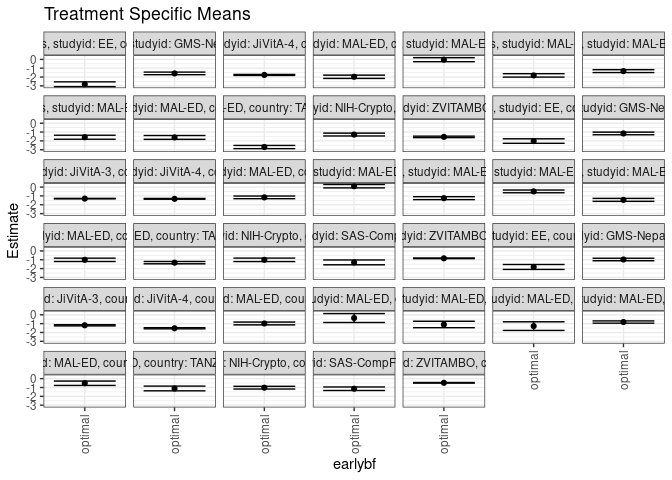

## Results Table

### Parameter: TSM

| agecat | studyid | country | intervention_level | baseline_level | estimate | ci_lower | ci_upper |
| --- | --- | --- | --- | --- | --- | --- | --- |
| Birth | EE | PAKISTAN | optimal | observed | -1.8148194 | -2.0954707 | -1.5341680 |
| Birth | GMS-Nepal | NEPAL | optimal | observed | -0.9682220 | -1.1092079 | -0.8272362 |
| Birth | JiVitA-3 | BANGLADESH | optimal | observed | -1.1860641 | -1.2532151 | -1.1189131 |
| Birth | JiVitA-4 | BANGLADESH | optimal | observed | -1.5250501 | -1.5907435 | -1.4593568 |
| Birth | MAL-ED | BANGLADESH | optimal | observed | -0.9821915 | -1.1412315 | -0.8231514 |
| Birth | MAL-ED | BRAZIL | optimal | observed | -0.3693164 | -0.8748587 | 0.1362259 |
| Birth | MAL-ED | INDIA | optimal | observed | -1.0975075 | -1.4624227 | -0.7325923 |
| Birth | MAL-ED | NEPAL | optimal | observed | -1.2801153 | -1.7683997 | -0.7918308 |
| Birth | MAL-ED | PERU | optimal | observed | -0.8180724 | -0.9462670 | -0.6898777 |
| Birth | MAL-ED | SOUTH AFRICA | optimal | observed | -0.5211756 | -0.7686038 | -0.2737474 |
| Birth | MAL-ED | TANZANIA, UNITED REPUBLIC OF | optimal | observed | -1.1130107 | -1.3811731 | -0.8448484 |
| Birth | NIH-Crypto | BANGLADESH | optimal | observed | -1.0233262 | -1.1769088 | -0.8697437 |
| Birth | SAS-CompFeed | INDIA | optimal | observed | -1.1408917 | -1.3386772 | -0.9431062 |
| Birth | ZVITAMBO | ZIMBABWE | optimal | observed | -0.4717836 | -0.5029787 | -0.4405885 |
| 6 months | EE | PAKISTAN | optimal | observed | -2.0191097 | -2.2741673 | -1.7640520 |
| 6 months | GMS-Nepal | NEPAL | optimal | observed | -1.1573767 | -1.3058695 | -1.0088840 |
| 6 months | JiVitA-3 | BANGLADESH | optimal | observed | -1.3049318 | -1.3287988 | -1.2810648 |
| 6 months | JiVitA-4 | BANGLADESH | optimal | observed | -1.3312125 | -1.3777098 | -1.2847152 |
| 6 months | MAL-ED | BANGLADESH | optimal | observed | -1.1646764 | -1.3165132 | -1.0128397 |
| 6 months | MAL-ED | BRAZIL | optimal | observed | 0.0973741 | -0.0939491 | 0.2886973 |
| 6 months | MAL-ED | INDIA | optimal | observed | -1.2540031 | -1.4194803 | -1.0885258 |
| 6 months | MAL-ED | NEPAL | optimal | observed | -0.4890653 | -0.6425316 | -0.3355991 |
| 6 months | MAL-ED | PERU | optimal | observed | -1.4485209 | -1.6143469 | -1.2826949 |
| 6 months | MAL-ED | SOUTH AFRICA | optimal | observed | -1.0074607 | -1.1943290 | -0.8205923 |
| 6 months | MAL-ED | TANZANIA, UNITED REPUBLIC OF | optimal | observed | -1.3264898 | -1.4550871 | -1.1978925 |
| 6 months | NIH-Crypto | BANGLADESH | optimal | observed | -1.0060209 | -1.2023086 | -0.8097333 |
| 6 months | SAS-CompFeed | INDIA | optimal | observed | -1.2967082 | -1.5697238 | -1.0236925 |
| 6 months | ZVITAMBO | ZIMBABWE | optimal | observed | -0.8363205 | -0.8714922 | -0.8011488 |
| 24 months | EE | PAKISTAN | optimal | observed | -2.8167236 | -3.0909511 | -2.5424961 |
| 24 months | GMS-Nepal | NEPAL | optimal | observed | -1.5901839 | -1.7384986 | -1.4418691 |
| 24 months | JiVitA-4 | BANGLADESH | optimal | observed | -1.7638457 | -1.8172203 | -1.7104711 |
| 24 months | MAL-ED | BANGLADESH | optimal | observed | -1.9705914 | -2.1559913 | -1.7851914 |
| 24 months | MAL-ED | BRAZIL | optimal | observed | -0.0367485 | -0.2638703 | 0.1903733 |
| 24 months | MAL-ED | INDIA | optimal | observed | -1.8157906 | -2.0074411 | -1.6241400 |
| 24 months | MAL-ED | NEPAL | optimal | observed | -1.3309580 | -1.4948180 | -1.1670981 |
| 24 months | MAL-ED | PERU | optimal | observed | -1.5875467 | -1.8133215 | -1.3617719 |
| 24 months | MAL-ED | SOUTH AFRICA | optimal | observed | -1.6069514 | -1.8230382 | -1.3908646 |
| 24 months | MAL-ED | TANZANIA, UNITED REPUBLIC OF | optimal | observed | -2.6943948 | -2.8762534 | -2.5125362 |
| 24 months | NIH-Crypto | BANGLADESH | optimal | observed | -1.2831994 | -1.4436540 | -1.1227448 |
| 24 months | ZVITAMBO | ZIMBABWE | optimal | observed | -1.5472800 | -1.6306907 | -1.4638693 |

### Parameter: E(Y)

| agecat | studyid | country | intervention_level | baseline_level | estimate | ci_lower | ci_upper |
| --- | --- | --- | --- | --- | --- | --- | --- |
| Birth | EE | PAKISTAN | observed | observed | -1.8713537 | -2.0647180 | -1.6779894 |
| Birth | GMS-Nepal | NEPAL | observed | observed | -1.0578481 | -1.1411010 | -0.9745953 |
| Birth | JiVitA-3 | BANGLADESH | observed | observed | -1.5896710 | -1.6089649 | -1.5703770 |
| Birth | JiVitA-4 | BANGLADESH | observed | observed | -1.5232908 | -1.5723277 | -1.4742539 |
| Birth | MAL-ED | BANGLADESH | observed | observed | -1.1218261 | -1.2566576 | -0.9869945 |
| Birth | MAL-ED | BRAZIL | observed | observed | -0.6760000 | -0.9521457 | -0.3998543 |
| Birth | MAL-ED | INDIA | observed | observed | -1.2221739 | -1.5203945 | -0.9239534 |
| Birth | MAL-ED | NEPAL | observed | observed | -0.8533333 | -1.2104864 | -0.4961803 |
| Birth | MAL-ED | PERU | observed | observed | -0.8827897 | -1.0001058 | -0.7654736 |
| Birth | MAL-ED | SOUTH AFRICA | observed | observed | -0.5709009 | -0.7569265 | -0.3848753 |
| Birth | MAL-ED | TANZANIA, UNITED REPUBLIC OF | observed | observed | -1.1556000 | -1.3655361 | -0.9456639 |
| Birth | NIH-Crypto | BANGLADESH | observed | observed | -0.9094945 | -0.9809370 | -0.8380521 |
| Birth | SAS-CompFeed | INDIA | observed | observed | -1.4072245 | -1.4817853 | -1.3326638 |
| Birth | ZVITAMBO | ZIMBABWE | observed | observed | -0.4895257 | -0.5113672 | -0.4676841 |
| 6 months | EE | PAKISTAN | observed | observed | -2.0838858 | -2.2054394 | -1.9623322 |
| 6 months | GMS-Nepal | NEPAL | observed | observed | -1.3175310 | -1.3993963 | -1.2356656 |
| 6 months | JiVitA-3 | BANGLADESH | observed | observed | -1.3130932 | -1.3362359 | -1.2899505 |
| 6 months | JiVitA-4 | BANGLADESH | observed | observed | -1.3447940 | -1.3820261 | -1.3075620 |
| 6 months | MAL-ED | BANGLADESH | observed | observed | -1.2056389 | -1.3233420 | -1.0879358 |
| 6 months | MAL-ED | BRAZIL | observed | observed | 0.0475758 | -0.0963508 | 0.1915023 |
| 6 months | MAL-ED | INDIA | observed | observed | -1.2115254 | -1.3298727 | -1.0931782 |
| 6 months | MAL-ED | NEPAL | observed | observed | -0.5615819 | -0.6741832 | -0.4489807 |
| 6 months | MAL-ED | PERU | observed | observed | -1.3236661 | -1.4316775 | -1.2156546 |
| 6 months | MAL-ED | SOUTH AFRICA | observed | observed | -1.0598800 | -1.1885688 | -0.9311912 |
| 6 months | MAL-ED | TANZANIA, UNITED REPUBLIC OF | observed | observed | -1.3687449 | -1.4907629 | -1.2467270 |
| 6 months | NIH-Crypto | BANGLADESH | observed | observed | -1.1986783 | -1.2700937 | -1.1272630 |
| 6 months | SAS-CompFeed | INDIA | observed | observed | -1.4018563 | -1.4810585 | -1.3226541 |
| 6 months | ZVITAMBO | ZIMBABWE | observed | observed | -0.8625370 | -0.8897591 | -0.8353150 |
| 24 months | EE | PAKISTAN | observed | observed | -2.6678252 | -2.8138884 | -2.5217620 |
| 24 months | GMS-Nepal | NEPAL | observed | observed | -1.8793783 | -1.9705101 | -1.7882464 |
| 24 months | JiVitA-4 | BANGLADESH | observed | observed | -1.7807218 | -1.8162478 | -1.7451958 |
| 24 months | MAL-ED | BANGLADESH | observed | observed | -1.9735782 | -2.1004502 | -1.8467062 |
| 24 months | MAL-ED | BRAZIL | observed | observed | 0.0061144 | -0.1625850 | 0.1748138 |
| 24 months | MAL-ED | INDIA | observed | observed | -1.8861894 | -2.0110006 | -1.7613783 |
| 24 months | MAL-ED | NEPAL | observed | observed | -1.3075877 | -1.4270718 | -1.1881037 |
| 24 months | MAL-ED | PERU | observed | observed | -1.7524710 | -1.8736426 | -1.6312994 |
| 24 months | MAL-ED | SOUTH AFRICA | observed | observed | -1.6365071 | -1.7722110 | -1.5008032 |
| 24 months | MAL-ED | TANZANIA, UNITED REPUBLIC OF | observed | observed | -2.6455607 | -2.7807256 | -2.5103959 |
| 24 months | NIH-Crypto | BANGLADESH | observed | observed | -1.4412646 | -1.5249156 | -1.3576135 |
| 24 months | ZVITAMBO | ZIMBABWE | observed | observed | -1.6006366 | -1.6621572 | -1.5391159 |

### Parameter: PAR

| agecat | studyid | country | intervention_level | baseline_level | estimate | ci_lower | ci_upper |
| --- | --- | --- | --- | --- | --- | --- | --- |
| Birth | EE | PAKISTAN | optimal | observed | -0.0565343 | -0.2677157 | 0.1546471 |
| Birth | GMS-Nepal | NEPAL | optimal | observed | -0.0896261 | -0.2031877 | 0.0239355 |
| Birth | JiVitA-3 | BANGLADESH | optimal | observed | -0.4036069 | -0.4689800 | -0.3382338 |
| Birth | JiVitA-4 | BANGLADESH | optimal | observed | 0.0017593 | -0.0443360 | 0.0478547 |
| Birth | MAL-ED | BANGLADESH | optimal | observed | -0.1396346 | -0.2458446 | -0.0334247 |
| Birth | MAL-ED | BRAZIL | optimal | observed | -0.3066836 | -0.7307726 | 0.1174054 |
| Birth | MAL-ED | INDIA | optimal | observed | -0.1246664 | -0.3272179 | 0.0778850 |
| Birth | MAL-ED | NEPAL | optimal | observed | 0.4267819 | 0.0549336 | 0.7986302 |
| Birth | MAL-ED | PERU | optimal | observed | -0.0647173 | -0.1176549 | -0.0117798 |
| Birth | MAL-ED | SOUTH AFRICA | optimal | observed | -0.0497253 | -0.2152739 | 0.1158233 |
| Birth | MAL-ED | TANZANIA, UNITED REPUBLIC OF | optimal | observed | -0.0425893 | -0.2243014 | 0.1391228 |
| Birth | NIH-Crypto | BANGLADESH | optimal | observed | 0.1138317 | -0.0129619 | 0.2406253 |
| Birth | SAS-CompFeed | INDIA | optimal | observed | -0.2663328 | -0.4099516 | -0.1227140 |
| Birth | ZVITAMBO | ZIMBABWE | optimal | observed | -0.0177420 | -0.0399316 | 0.0044476 |
| 6 months | EE | PAKISTAN | optimal | observed | -0.0647762 | -0.2892478 | 0.1596955 |
| 6 months | GMS-Nepal | NEPAL | optimal | observed | -0.1601543 | -0.2850685 | -0.0352400 |
| 6 months | JiVitA-3 | BANGLADESH | optimal | observed | -0.0081614 | -0.0111726 | -0.0051502 |
| 6 months | JiVitA-4 | BANGLADESH | optimal | observed | -0.0135815 | -0.0402297 | 0.0130666 |
| 6 months | MAL-ED | BANGLADESH | optimal | observed | -0.0409624 | -0.1366168 | 0.0546920 |
| 6 months | MAL-ED | BRAZIL | optimal | observed | -0.0497983 | -0.1833680 | 0.0837714 |
| 6 months | MAL-ED | INDIA | optimal | observed | 0.0424776 | -0.0629914 | 0.1479467 |
| 6 months | MAL-ED | NEPAL | optimal | observed | -0.0725166 | -0.1653469 | 0.0203137 |
| 6 months | MAL-ED | PERU | optimal | observed | 0.1248548 | -0.0043748 | 0.2540845 |
| 6 months | MAL-ED | SOUTH AFRICA | optimal | observed | -0.0524193 | -0.1925870 | 0.0877483 |
| 6 months | MAL-ED | TANZANIA, UNITED REPUBLIC OF | optimal | observed | -0.0422551 | -0.1077309 | 0.0232207 |
| 6 months | NIH-Crypto | BANGLADESH | optimal | observed | -0.1926574 | -0.3753804 | -0.0099345 |
| 6 months | SAS-CompFeed | INDIA | optimal | observed | -0.1051481 | -0.3404644 | 0.1301682 |
| 6 months | ZVITAMBO | ZIMBABWE | optimal | observed | -0.0262166 | -0.0490808 | -0.0033523 |
| 24 months | EE | PAKISTAN | optimal | observed | 0.1488984 | -0.0699040 | 0.3677008 |
| 24 months | GMS-Nepal | NEPAL | optimal | observed | -0.2891944 | -0.4190731 | -0.1593157 |
| 24 months | JiVitA-4 | BANGLADESH | optimal | observed | -0.0168761 | -0.0593438 | 0.0255916 |
| 24 months | MAL-ED | BANGLADESH | optimal | observed | -0.0029868 | -0.1357298 | 0.1297562 |
| 24 months | MAL-ED | BRAZIL | optimal | observed | 0.0428629 | -0.1229169 | 0.2086427 |
| 24 months | MAL-ED | INDIA | optimal | observed | -0.0703989 | -0.2207734 | 0.0799756 |
| 24 months | MAL-ED | NEPAL | optimal | observed | 0.0233703 | -0.0803774 | 0.1271181 |
| 24 months | MAL-ED | PERU | optimal | observed | -0.1649243 | -0.3614949 | 0.0316463 |
| 24 months | MAL-ED | SOUTH AFRICA | optimal | observed | -0.0295557 | -0.2000597 | 0.1409483 |
| 24 months | MAL-ED | TANZANIA, UNITED REPUBLIC OF | optimal | observed | 0.0488340 | -0.0850682 | 0.1827363 |
| 24 months | NIH-Crypto | BANGLADESH | optimal | observed | -0.1580652 | -0.3129340 | -0.0031964 |
| 24 months | ZVITAMBO | ZIMBABWE | optimal | observed | -0.0533565 | -0.1157675 | 0.0090544 |